# Tabular data - Bivariate relationships III: Numerical-Numerical

1. Using dates and numeric data
2. Two numeric variables
3. Deliverable II (option 3)

Let’s use these [Covid data set](https://www.mass.gov/info-details/archive-of-covid-19-cases-2020-2021) from Massachusetts (previously pre-processed):

```r
rm(list = ls())

# collecting the data
link="https://github.com/DACSS-Visual/tabular_bivar_numnum/raw/main/data/covidMA.rds"
covidMA=readRDS(url(link))
```

This is what we have:

```r
str(covidMA)
```

```
## 'data.frame':    6500 obs. of  6 variables:
##  $ Date          : POSIXct, format: "2020-08-19" "2020-08-19" ...
##  $ County        : chr  "Barnstable" "Berkshire" "Bristol" "Dukes" ...
##  $ cases         : num  0 1 12 0 56 0 12 9 42 0 ...
##  $ deaths        : num  2 0 0 0 1 0 3 0 10 0 ...
##  $ yearMonth     : POSIXct, format: "2020-08-01" "2020-08-01" ...
##  $ yearMonth_text: Ord.factor w/ 17 levels "2020-Aug"<"2020-Sep"<..: 1 1 1 1 1 1 1 1 1 1 ...
```

## Numeric & Date

I have a date variable in this data set:

```r
summary(covidMA$Date)
```

```
##                       Min.                    1st Qu.
## "2020-08-19 00:00:00.0000" "2020-12-07 00:00:00.0000"
##                     Median                       Mean
## "2021-03-28 00:00:00.0000" "2021-04-05 23:51:48.1846"
##                    3rd Qu.                       Max.
## "2021-07-28 00:00:00.0000" "2021-12-31 00:00:00.0000"
```

Let me see the monthly situation:

```r
covidMA_monthly=aggregate(data=covidMA,
          cbind(cases,deaths)~yearMonth,sum)

covidMA_monthly$yearMonth=as.Date(covidMA_monthly$yearMonth)
covidMA_monthly
```

```
##     yearMonth  cases deaths
## 1  2020-08-01   3951    213
## 2  2020-09-01  11061    409
## 3  2020-10-01  24748    535
## 4  2020-11-01  63522    755
## 5  2020-12-01 140650   1674
## 6  2021-01-01 138301   2153
## 7  2021-02-01  52148   1541
## 8  2021-03-01  47686   1057
## 9  2021-04-01  47682    427
## 10 2021-05-01  14969    274
## 11 2021-06-01   2798    122
## 12 2021-07-01   8497     97
## 13 2021-08-01  36964    165
## 14 2021-09-01  48233    383
## 15 2021-10-01  36382    371
## 16 2021-11-01  59993    411
## 17 2021-12-01 204178    869
```

As we know, long shape works better:

```r
covidMA_monthly_long=reshape2::melt(covidMA_monthly,
                                    variable.name = 'type',
                                    value.name = 'value',
                                    id.vars='yearMonth')
covidMA_monthly_long
```

```
##     yearMonth   type  value
## 1  2020-08-01  cases   3951
## 2  2020-09-01  cases  11061
## 3  2020-10-01  cases  24748
## 4  2020-11-01  cases  63522
## 5  2020-12-01  cases 140650
## 6  2021-01-01  cases 138301
## 7  2021-02-01  cases  52148
## 8  2021-03-01  cases  47686
## 9  2021-04-01  cases  47682
## 10 2021-05-01  cases  14969
## 11 2021-06-01  cases   2798
## 12 2021-07-01  cases   8497
## 13 2021-08-01  cases  36964
## 14 2021-09-01  cases  48233
```

[output cut: 20 more lines]

Let’s get our lines:

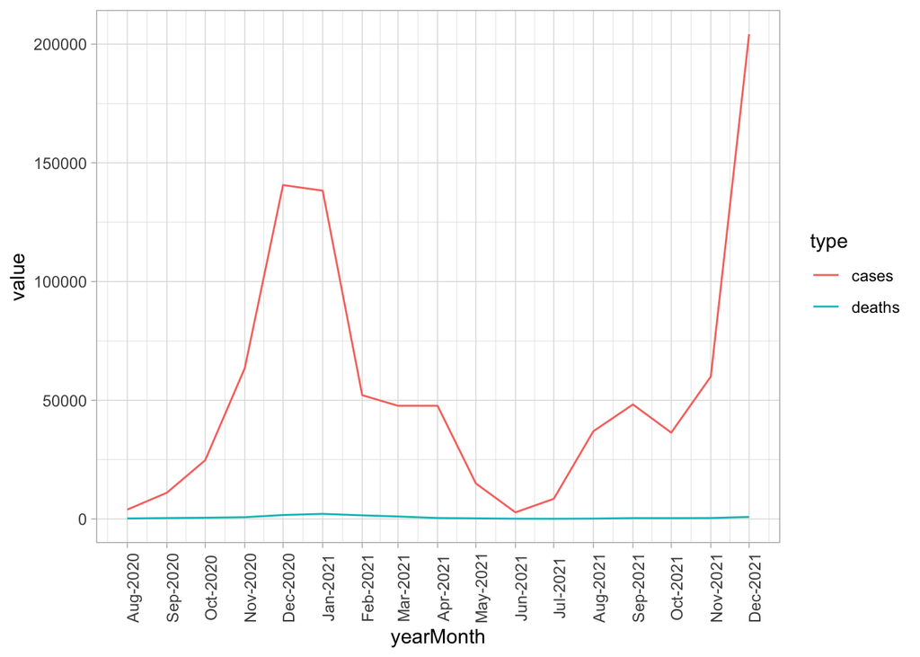

```r
# want to subset?
min <- as.Date("2020-08-01")
max <- as.Date("2021-12-01")



library(ggplot2)
base=ggplot(covidMA_monthly_long,
            aes(x=yearMonth)) + theme_light()

covidLines=base  + geom_line(aes(y=value,color=type) )

covidLines= covidLines + scale_x_date(limits = c(min, max), #subset?
                                      date_breaks = "1 month",
                                      date_labels = "%b-%Y") +
    theme(axis.text.x = element_text(angle = 90))

covidLines
```

Alternatively, a **logged axis** allow you to see hidden distributions:

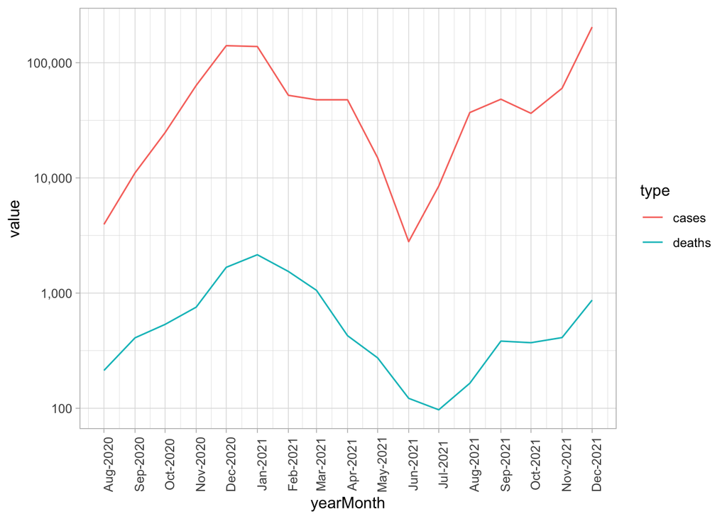

```r
covidLines  + scale_y_log10(labels = scales::comma)
```

What about faceting deaths by county?

Let’s prepare the data:

```r
covidMA_County_monthly=aggregate(data=covidMA,
          cbind(cases,deaths)~yearMonth+ County,sum)


head(covidMA_County_monthly)
```

```
##    yearMonth     County cases deaths
## 1 2020-08-01 Barnstable    46      3
## 2 2020-09-01 Barnstable   159     10
## 3 2020-10-01 Barnstable   244     11
## 4 2020-11-01 Barnstable  1018      7
## 5 2020-12-01 Barnstable  2349     46
## 6 2021-01-01 Barnstable  3307    104
```

First plot (only deaths):

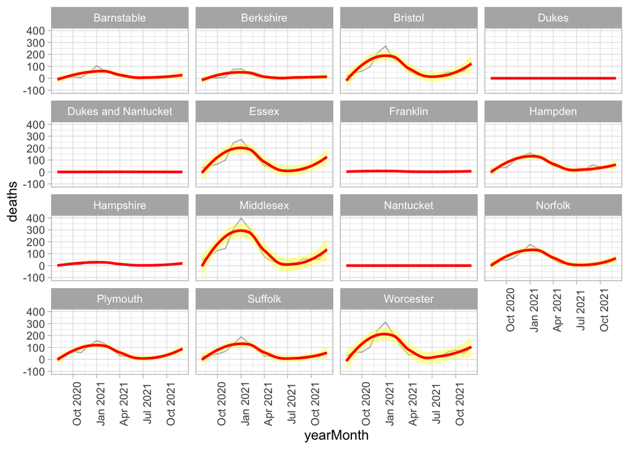

```r
base=ggplot(data=covidMA_County_monthly,aes(x=yearMonth,
                y=deaths)) + theme_light()
monthly= base  + geom_line(alpha=0.3)  +
    theme(axis.text.x = element_text(angle = 90))

# adding a trend:
monthly = monthly + stat_smooth(color = "red",
                      fill = "yellow",
                      method = "loess")
monthly + facet_wrap(~County)
```

Let’s try to highlight severity by reordering and faceting in one row:

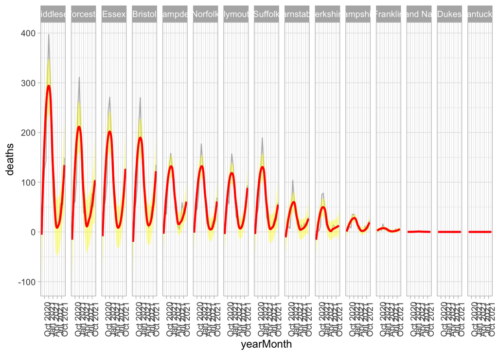

```r
monthly + facet_wrap(~reorder(County,-deaths),nrow = 1)
```

Are we really highlighting severity? Let’s compute the rate of deaths by cases:

```r
rateDeathCases=covidMA_County_monthly$deaths/covidMA_County_monthly$cases
covidMA_County_monthly$deaths_by100cases=100*rateDeathCases

summary(covidMA_County_monthly$deaths_by100cases)
```

```
##    Min. 1st Qu.  Median    Mean 3rd Qu.    Max.    NA's
##  0.0000  0.5305  1.2391     Inf  2.5237     Inf      12
```

This summary is worth being shared and discussed, could be part of annotations, or some table or comment somewhere else **outside** the visual:

- The divisions by zero:

```r
covidMA_County_monthly[is.infinite(covidMA_County_monthly$deaths_by100cases),]
```

```
##     yearMonth              County cases deaths deaths_by100cases
## 71 2020-10-01 Dukes and Nantucket     0      1               Inf
## 76 2021-03-01 Dukes and Nantucket     0      2               Inf
## 77 2021-04-01 Dukes and Nantucket     0      1               Inf
## 80 2021-07-01 Dukes and Nantucket     0      1               Inf
## 82 2021-09-01 Dukes and Nantucket     0      1               Inf
```

- The non numerical results:

```r
covidMA_County_monthly[is.nan(covidMA_County_monthly$deaths_by100cases),]
```

```
##     yearMonth              County cases deaths deaths_by100cases
## 69 2020-08-01 Dukes and Nantucket     0      0               NaN
## 70 2020-09-01 Dukes and Nantucket     0      0               NaN
## 72 2020-11-01 Dukes and Nantucket     0      0               NaN
## 73 2020-12-01 Dukes and Nantucket     0      0               NaN
## 74 2021-01-01 Dukes and Nantucket     0      0               NaN
## 75 2021-02-01 Dukes and Nantucket     0      0               NaN
## 78 2021-05-01 Dukes and Nantucket     0      0               NaN
## 79 2021-06-01 Dukes and Nantucket     0      0               NaN
## 81 2021-08-01 Dukes and Nantucket     0      0               NaN
## 83 2021-10-01 Dukes and Nantucket     0      0               NaN
## 84 2021-11-01 Dukes and Nantucket     0      0               NaN
## 85 2021-12-01 Dukes and Nantucket     0      0               NaN
```

- The zero deaths:

```r
covidMA_County_monthly[covidMA_County_monthly$deaths_by100cases==0 &
                            !is.nan(covidMA_County_monthly$deaths_by100cases)   ,]
```

```
##      yearMonth    County cases deaths deaths_by100cases
## 18  2020-08-01 Berkshire    32      0                 0
## 52  2020-08-01     Dukes     6      0                 0
## 53  2020-09-01     Dukes     8      0                 0
## 54  2020-10-01     Dukes    25      0                 0
## 55  2020-11-01     Dukes   184      0                 0
## 56  2020-12-01     Dukes   210      0                 0
## 57  2021-01-01     Dukes   292      0                 0
## 58  2021-02-01     Dukes    88      0                 0
## 59  2021-03-01     Dukes   100      0                 0
## 60  2021-04-01     Dukes   311      0                 0
## 61  2021-05-01     Dukes   136      0                 0
## 62  2021-06-01     Dukes     8      0                 0
## 63  2021-07-01     Dukes    28      0                 0
## 64  2021-08-01     Dukes   244      0                 0
```

[output cut: 25 more lines]

For the plot, we need the full data with none of the cases above, keeping in mind that we might use semilog axes:

```r
covidMA_County_monthly_Full=covidMA_County_monthly[!is.nan(covidMA_County_monthly$deaths_by100cases) &
                           !is.infinite(covidMA_County_monthly$deaths_by100cases) &
                        covidMA_County_monthly$deaths_by100cases>0,]
```